# Movie Recommendation System

```python
#from google.colab import drive
#drive.mount('/content/drive')
```

Observation: mounting the Google drive on Colab

```python
conda install -c "conda-forge/label/cf202003" scikit-surprise
```

```
Solving environment: ...working... done

# All requested packages already installed.
```

[output not shown]

Observation: Installing surprise

```python
import warnings
warnings.filterwarnings('ignore')

import numpy as np
import pandas as pd

import matplotlib.pyplot as plt

import seaborn as sns

from collections import defaultdict

from surprise import accuracy

from surprise.reader import Reader

from surprise.dataset import Dataset

from surprise.model_selection import GridSearchCV

from surprise.model_selection import train_test_split

from surprise.prediction_algorithms.knns import KNNBasic

from surprise.prediction_algorithms.matrix_factorization import SVD

from surprise.model_selection import KFold
```

Observation: Importing Datasets

```python
rating = pd.read_csv("C:\\Users\\bilal\\Documents\\ratings.csv")
```

Observation: Loading the data

```python
rating.info()
```

```
<class 'pandas.core.frame.DataFrame'>
RangeIndex: 100004 entries, 0 to 100003
Data columns (total 4 columns):
 #   Column     Non-Null Count   Dtype
---  ------     --------------   -----
 0   userId     100004 non-null  int64
 1   movieId    100004 non-null  int64
 2   rating     100004 non-null  float64
 3   timestamp  100004 non-null  int64
dtypes: float64(1), int64(3)
memory usage: 3.1 MB
```

Observation: check the info of the data

```python
rating = rating.drop(['timestamp'], axis=1)
```

Observation: Dropping timestamp column

```python
rating.head(5)
```

|  | userId | movieId | rating |
| --- | --- | --- | --- |
| 0 | 1 | 31 | 2.5 |
| 1 | 1 | 1029 | 3.0 |
| 2 | 1 | 1061 | 3.0 |
| 3 | 1 | 1129 | 2.0 |
| 4 | 1 | 1172 | 4.0 |

Observation: Printing the top 5 rows of the dataset

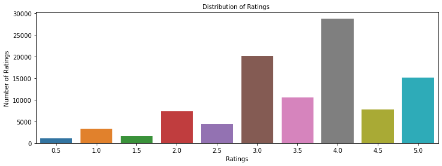

```python
plt.figure(figsize = (12, 4))
sns.countplot(x="rating", data=rating)

plt.tick_params(labelsize = 10)
plt.title("Distribution of Ratings ", fontsize = 10)
plt.xlabel("Ratings", fontsize = 10)
plt.ylabel("Number of Ratings", fontsize = 10)
plt.ticklabel_format(useOffset=False, style='plain', axis='y')
plt.show()
```

Observation: Describe the distribution of ratings

```python
rating['userId'].nunique()
```

```
671
```

Observation: Total number of unique users

```python
rating['movieId'].nunique()
```

```
9066
```

Observation: Total number of unique movies

```python
rating.groupby(['userId', 'movieId']).count()
```

| userId | movieId | rating |
| --- | --- | --- |
| 1 | 31 | 1 |
|  | 1029 | 1 |
|  | 1061 | 1 |
|  | 1129 | 1 |
|  | 1172 | 1 |
| ... | ... | ... |
| 671 | 6268 | 1 |
|  | 6269 | 1 |
|  | 6365 | 1 |
|  | 6385 | 1 |
|  | 6565 | 1 |

100004 rows × 1 columns

```python
rating.groupby(['userId', 'movieId']).count()['rating'].sum()
```

```
100004
```

Observation: sum of movie in which the same user interacted with it more than once

```python
rating['movieId'].value_counts().head()
```

```
356    341
296    324
318    311
593    304
260    291
Name: movieId, dtype: int64
```

Observation: most interacted movie in the dataset

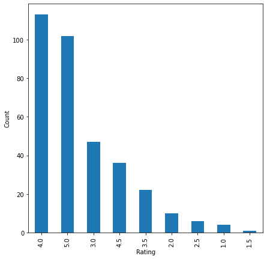

```python
plt.figure(figsize=(7,7))

rating[rating['movieId'] == 356]['rating'].value_counts().plot(kind='bar')

plt.xlabel('Rating')

plt.ylabel('Count')

plt.show()
```

Observation: Plotting distributions of ratings for 341 interactions with movieid 356

```python
rating['userId'].value_counts().head()
```

```
547    2391
564    1868
624    1735
15     1700
73     1610
Name: userId, dtype: int64
```

Observation: user interacted the most with any movie in the dataset

```python
count_interactions = rating.groupby('userId').count()['movieId']
count_interactions
```

```
userId
1       20
2       76
3       51
4      204
5      100
      ...
667     68
668     20
669     37
670     31
671    115
Name: movieId, Length: 671, dtype: int64
```

Observation: user-movie interactions distribution

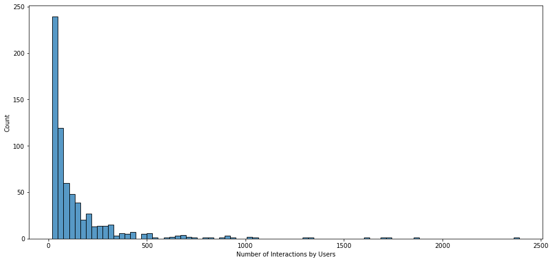

```python
plt.figure(figsize=(15,7))

sns.histplot(count_interactions)

plt.xlabel('Number of Interactions by Users')

plt.show()
```

Observation: Plotting user-movie interactions distribution

```python
average_rating = rating.groupby('movieId').mean()['rating']
count_rating = rating.groupby('movieId').count()['rating']
final_rating = pd.DataFrame({'avg_rating':average_rating, 'rating_count':count_rating})
```

Observation: Calculating average ratings, the count of ratings and making a dataframe with the count and average of ratings

```python
final_rating.head()
```

| movieId | avg_rating | rating_count |
| --- | --- | --- |
| 1 | 3.872470 | 247 |
| 2 | 3.401869 | 107 |
| 3 | 3.161017 | 59 |
| 4 | 2.384615 | 13 |
| 5 | 3.267857 | 56 |

Observation: Give the first five rows of the final rating

```python
def top_n_movies(data, n, min_interaction=100):

    recommendations = data[data['rating_count'] >= min_interaction]

    recommendations = recommendations.sort_values(by='avg_rating', ascending=False)

    return recommendations.index[:n]
```

Observation: Finding movies with minimum number of interactions and sorting values w.r.t average rating

```python
list(top_n_movies(final_rating, 5, 50))
```

```
[858, 318, 969, 913, 1221]
```

Observations: Recommending top 5 movies with 50 minimum interactions based on popularity

```python
list(top_n_movies(final_rating, 5, 100))
```

```
[858, 318, 1221, 50, 527]
```

Observation: Recommending top 5 movies with 100 minimum interactions based on popularity

```python
list(top_n_movies(final_rating, 5, 200))
```

```
[858, 318, 50, 527, 608]
```

Observation: Recommending top 5 movies with 200 minimum interactions based on popularity

```python
reader = Reader(rating_scale=(0, 5))

data = Dataset.load_from_df(rating[['userId', 'movieId', 'rating']], reader)

trainset, testset = train_test_split(data, test_size=0.2, random_state=42)
```

Observation: Instantiating Reader scale with expected rating scale, Loading the rating dataset, splitting the data into train and test dataset

```python
sim_options = {'name': 'cosine',
               'user_based': True}

algo_knn_user = KNNBasic(sim_options=sim_options,verbose=False)

algo_knn_user.fit(trainset)
predictions = algo_knn_user.test(testset)

accuracy.rmse(predictions)
```

```
RMSE: 0.9925
```

```
0.9924509041520163
```

Observation: Train the algorithm on the trainset, and predict ratings for the testset and compute RMSE

What is the RMSE for baseline user based collaborative filtering recommendation system? As we can see from above, these baseline model has RMSE= 0.9925 on test set, we will try to improve this number later by using GridSearchCV tuning different hyperparameters of this algorithm

```python
algo_knn_user.predict(4, 10, r_ui=4, verbose=True)
```

```
user: 4          item: 10         r_ui = 4.00   est = 3.62   {'actual_k': 40, 'was_impossible': False}
```

```
Prediction(uid=4, iid=10, r_ui=4, est=3.6244912065910952, details={'actual_k': 40, 'was_impossible': False})
```

Observation: predict rating for an user with userId=4 and for movieId=10

```python
algo_knn_user.predict(4, 3, verbose=True)
```

```
user: 4          item: 3          r_ui = None   est = 3.20   {'actual_k': 40, 'was_impossible': False}
```

```
Prediction(uid=4, iid=3, r_ui=None, est=3.202703552548654, details={'actual_k': 40, 'was_impossible': False})
```

Observation: predict the rating for the same userId=4 but for a movie which this user has not interacted before i.e. movieId=3

```python
algo_knn_user.predict(0,3, verbose=True)
```

```
user: 0          item: 3          r_ui = None   est = 3.55   {'was_impossible': True, 'reason': 'User and/or item is unkown.'}
```

```
Prediction(uid=0, iid=3, r_ui=None, est=3.5459045285801785, details={'was_impossible': True, 'reason': 'User and/or item is unkown.'})
```

```python
param_grid = {'k': [20, 30, 40], 'min_k': [3, 6, 9],
              'sim_options': {'name': ['msd', 'cosine'],
                              'user_based': [True]}
              }

gs = GridSearchCV(KNNBasic, param_grid, measures=['rmse', 'mae'], cv=3, n_jobs=-1)

gs.fit(data)

print(gs.best_score['rmse'])

print(gs.best_params['rmse'])
```

```
0.965285459914116
{'k': 20, 'min_k': 3, 'sim_options': {'name': 'msd', 'user_based': True}}
```

Observation: grid search is complete, we can get the optimal values for each of those hyperparameters as shown above.

```python
results_df = pd.DataFrame.from_dict(gs.cv_results)
results_df.head()
```

|  | split0_test_rmse | split1_test_rmse | split2_test_rmse | mean_test_rmse | std_test_rmse | rank_test_rmse | split0_test_mae | split1_test_mae | split2_test_mae | mean_test_mae | std_test_mae | rank_test_mae | mean_fit_time | std_fit_time | mean_test_time | std_test_time | params | param_k | param_min_k | param_sim_options |
| --- | --- | --- | --- | --- | --- | --- | --- | --- | --- | --- | --- | --- | --- | --- | --- | --- | --- | --- | --- | --- |
| 0 | 0.968747 | 0.959650 | 0.967459 | 0.965285 | 0.004019 | 1 | 0.742686 | 0.737836 | 0.744651 | 0.741725 | 0.002864 | 1 | 0.504634 | 0.011026 | 7.700160 | 0.262924 | {'k': 20, 'min_k': 3, 'sim_options': {'name': ... | 20 | 3 | {'name': 'msd', 'user_based': True} |
| 1 | 0.996994 | 0.989338 | 0.996744 | 0.994359 | 0.003552 | 14 | 0.769547 | 0.765120 | 0.770962 | 0.768543 | 0.002489 | 12 | 2.000357 | 0.057624 | 8.294713 | 0.231548 | {'k': 20, 'min_k': 3, 'sim_options': {'name': ... | 20 | 3 | {'name': 'cosine', 'user_based': True} |
| 2 | 0.971613 | 0.962892 | 0.969736 | 0.968081 | 0.003748 | 3 | 0.745389 | 0.740636 | 0.747004 | 0.744343 | 0.002703 | 2 | 0.734495 | 0.193181 | 7.526454 | 0.254127 | {'k': 20, 'min_k': 6, 'sim_options': {'name': ... | 20 | 6 | {'name': 'msd', 'user_based': True} |
| 3 | 0.998498 | 0.991042 | 0.997463 | 0.995668 | 0.003298 | 15 | 0.771124 | 0.766663 | 0.771982 | 0.769923 | 0.002332 | 15 | 2.053926 | 0.143182 | 7.246112 | 0.146307 | {'k': 20, 'min_k': 6, 'sim_options': {'name': ... | 20 | 6 | {'name': 'cosine', 'user_based': True} |
| 4 | 0.977246 | 0.971438 | 0.976659 | 0.975115 | 0.002610 | 7 | 0.750764 | 0.747263 | 0.751883 | 0.749970 | 0.001968 | 7 | 0.755133 | 0.206225 | 7.061620 | 0.007313 | {'k': 20, 'min_k': 9, 'sim_options': {'name': ... | 20 | 9 | {'name': 'msd', 'user_based': True} |

Observation: analysing evaluation metrics - RMSE and MAE at each and every split to analyze the impact of each value of hyperparameters

```python
sim_options = {'name': 'cosine',
               'user_based': True}

similarity_algo_optimized_user = KNNBasic(sim_options=sim_options, k=40, min_k=6,Verbose=False)

similarity_algo_optimized_user.fit(trainset)

predictions = similarity_algo_optimized_user.test(testset)

accuracy.rmse(predictions)
```

```
Computing the cosine similarity matrix...
Done computing similarity matrix.
RMSE: 0.9908
```

```
0.9907613369496804
```

```python
similarity_algo_optimized_user.predict(4,10, r_ui=4, verbose=True)
```

```
user: 4          item: 10         r_ui = 4.00   est = 3.62   {'actual_k': 40, 'was_impossible': False}
```

```
Prediction(uid=4, iid=10, r_ui=4, est=3.6244912065910952, details={'actual_k': 40, 'was_impossible': False})
```

Observation: Predicted rating for an user with userId =4 and for movieId= 10 and movieId=3 using tuned user based collaborative filtering?

```python
similarity_algo_optimized_user.predict(0,3, verbose=True)
```

```
user: 0          item: 3          r_ui = None   est = 3.55   {'was_impossible': True, 'reason': 'User and/or item is unkown.'}
```

```
Prediction(uid=0, iid=3, r_ui=None, est=3.5459045285801785, details={'was_impossible': True, 'reason': 'User and/or item is unkown.'})
```

```python
similarity_algo_optimized_user.get_neighbors(4, k=5)
```

```
[357, 220, 590, 491, 647]
```

```python
def get_recommendations(data, user_id, top_n, algo):

    recommendations = []

    user_item_interactions_matrix = data.pivot(index='userId', columns='movieId', values='rating')

    non_interacted_movies = user_item_interactions_matrix.loc[user_id][user_item_interactions_matrix.loc[user_id].isnull()].index.tolist()

    for item_id in non_interacted_movies:

        est = algo.predict(user_id, item_id).est

        recommendations.append((item_id, est))

    recommendations.sort(key=lambda x: x[1], reverse=True)

    return recommendations[:top_n]
```

Observation: Implementing the recommendation algorithm based on optimized KNNBasic model

```python
recommendations = get_recommendations(rating, 4, 5, similarity_algo_optimized_user)
```

Observation: Predicted top 5 movies for userId=4 with similarity based recommendation system

```python
recommendations
```

```
[(98491, 4.832340578646058),
 (116, 4.753206589295344),
 (6669, 4.748048450384675),
 (1221, 4.662571141751736),
 (1192, 4.65824768595177)]
```

Observation: Predict the top 5 movies for userId=4 with similarity based recommendation system

```python
sim_options = {'name': 'cosine',
               'user_based': False}

algo_knn_item = KNNBasic(sim_options=sim_options,verbose=False)

algo_knn_item.fit(trainset)

predictions = algo_knn_item.test(testset)

accuracy.rmse(predictions)
```

```
RMSE: 1.0032
```

```
1.003221450633729
```

Observation: Item based Collaborative Filtering Recommendation System

What is the RMSE for baseline item based collaborative filtering recommendation system ? Baseline model has RMSE=1.0032 on test set, we will try to improve this number later by using GridSearchCV tuning different hyperparameters of this algorithm

```python
algo_knn_item.predict(4,10, r_ui=4, verbose=True)
```

```
user: 4          item: 10         r_ui = 4.00   est = 4.37   {'actual_k': 40, 'was_impossible': False}
```

```
Prediction(uid=4, iid=10, r_ui=4, est=4.373794871885004, details={'actual_k': 40, 'was_impossible': False})
```

Observation: Predicted rating for an user with userId =4 and for movieId= 10 and movieId=3?

```python
algo_knn_item.predict(0,3, verbose=True)
```

```
user: 0          item: 3          r_ui = None   est = 3.55   {'was_impossible': True, 'reason': 'User and/or item is unkown.'}
```

```
Prediction(uid=0, iid=3, r_ui=None, est=3.5459045285801785, details={'was_impossible': True, 'reason': 'User and/or item is unkown.'})
```

```python
param_grid = {'k': [20, 30,40], 'min_k': [3,6,9],
              'sim_options': {'name': ['msd', 'cosine'],
                              'user_based': [False]}
              }

grid_obj = GridSearchCV(KNNBasic, param_grid, measures=['rmse', 'mae'], cv=3)

grid_obj.fit(data)

print(grid_obj.best_score['rmse'])

print(grid_obj.best_params['rmse'])
```

[output not shown]

[output cut: 55 more lines]

[output not shown]

Observation: Perform hyperparameter tuning for the baseline item based collaborative filtering recommendation system and find the RMSE for tuned item based collaborative filtering recommendation system

```python
results_df = pd.DataFrame.from_dict(grid_obj.cv_results)
results_df.head()
```

|  | split0_test_rmse | split1_test_rmse | split2_test_rmse | mean_test_rmse | std_test_rmse | rank_test_rmse | split0_test_mae | split1_test_mae | split2_test_mae | mean_test_mae | std_test_mae | rank_test_mae | mean_fit_time | std_fit_time | mean_test_time | std_test_time | params | param_k | param_min_k | param_sim_options |
| --- | --- | --- | --- | --- | --- | --- | --- | --- | --- | --- | --- | --- | --- | --- | --- | --- | --- | --- | --- | --- |
| 0 | 0.950943 | 0.947969 | 0.955288 | 0.951400 | 0.003005 | 8 | 0.733509 | 0.733837 | 0.737936 | 0.735094 | 0.002014 | 7 | 3.793370 | 0.044882 | 10.158169 | 0.054600 | {'k': 20, 'min_k': 3, 'sim_options': {'name': ... | 20 | 3 | {'name': 'msd', 'user_based': False} |
| 1 | 1.013327 | 1.008249 | 1.018114 | 1.013230 | 0.004028 | 16 | 0.789593 | 0.787462 | 0.794701 | 0.790586 | 0.003037 | 16 | 13.920127 | 0.878997 | 9.922068 | 0.393782 | {'k': 20, 'min_k': 3, 'sim_options': {'name': ... | 20 | 3 | {'name': 'cosine', 'user_based': False} |
| 2 | 0.950735 | 0.947854 | 0.955479 | 0.951356 | 0.003144 | 7 | 0.733489 | 0.733817 | 0.738174 | 0.735160 | 0.002136 | 8 | 4.025264 | 0.187523 | 9.952272 | 0.111256 | {'k': 20, 'min_k': 6, 'sim_options': {'name': ... | 20 | 6 | {'name': 'msd', 'user_based': False} |
| 3 | 1.013267 | 1.008259 | 1.018176 | 1.013234 | 0.004049 | 17 | 0.789641 | 0.787537 | 0.794898 | 0.790692 | 0.003096 | 17 | 13.192406 | 0.281215 | 9.764030 | 0.099264 | {'k': 20, 'min_k': 6, 'sim_options': {'name': ... | 20 | 6 | {'name': 'cosine', 'user_based': False} |
| 4 | 0.951779 | 0.948343 | 0.955990 | 0.952037 | 0.003127 | 9 | 0.734163 | 0.734254 | 0.738616 | 0.735678 | 0.002078 | 9 | 3.592614 | 0.044195 | 9.031843 | 0.106141 | {'k': 20, 'min_k': 9, 'sim_options': {'name': ... | 20 | 9 | {'name': 'msd', 'user_based': False} |

Observation: Below we are analysing evaluation metrics - RMSE and MAE at each and every split to analyze the impact of each value of hyperparameters

```python
similarity_algo_optimized_item = KNNBasic(sim_options={'name': 'msd', 'user_based': False}, k=30, min_k=6,verbose=False)

similarity_algo_optimized_item.fit(trainset)

predictions = similarity_algo_optimized_item.test(testset)

accuracy.rmse(predictions)
```

```
RMSE: 0.9465
```

```
0.9465120620317036
```

```python
similarity_algo_optimized_item.predict(4,10, r_ui=4, verbose=True)
```

```
user: 4          item: 10         r_ui = 4.00   est = 4.30   {'actual_k': 30, 'was_impossible': False}
```

```
Prediction(uid=4, iid=10, r_ui=4, est=4.298279280483517, details={'actual_k': 30, 'was_impossible': False})
```

Observation: predict rating for an user with userId=4 and for movieId=10 with the optimized model as shown below

```python
similarity_algo_optimized_item.predict(4, 3, verbose=True)
```

```
user: 4          item: 3          r_ui = None   est = 3.86   {'actual_k': 30, 'was_impossible': False}
```

```
Prediction(uid=4, iid=3, r_ui=None, est=3.859023126306401, details={'actual_k': 30, 'was_impossible': False})
```

Observation: predict the rating for the same userId=4 but for a movie which this user has not interacted before i.e. movieId=3, by using the optimized model:

```python
similarity_algo_optimized_item.get_neighbors(3, k=5)
```

```
[31, 37, 42, 48, 73]
```

Observation: finding 5 most similar items to the movieId=3 based on the msd distance metric

```python
recommendations = get_recommendations(rating, 4, 5, similarity_algo_optimized_item)
```

Observation: Predicted top 5 movies for userId=4 with similarity based recommendation system

```python
recommendations
```

```
[(84, 5), (1040, 5), (2481, 5), (3515, 5), (4521, 5)]
```

Observation: Predict the top 5 movies for userId=4 with similarity based recommendation system

```python
algo_svd = SVD()

algo_svd.fit(trainset)

predictions = algo_svd.test(testset)

accuracy.rmse(predictions)
```

```
RMSE: 0.9041
```

```
0.9040555020358726
```

Observation: Build a baseline matrix factorization recommendation system

```python
algo_svd.predict(4, 10, r_ui=4, verbose=True)
```

```
user: 4          item: 10         r_ui = 4.00   est = 4.21   {'was_impossible': False}
```

```
Prediction(uid=4, iid=10, r_ui=4, est=4.209500797386506, details={'was_impossible': False})
```

Observation: Predict rating for an user with userId=4 and for movieId=10

```python
algo_svd.predict(0, 3, verbose=True)
```

```
user: 0          item: 3          r_ui = None   est = 3.14   {'was_impossible': False}
```

```
Prediction(uid=0, iid=3, r_ui=None, est=3.1394195024712515, details={'was_impossible': False})
```

```python
param_grid = {'n_epochs': [10, 20, 30], 'lr_all': [0.001, 0.005, 0.01],
              'reg_all': [0.2, 0.4, 0.6]}

gs = GridSearchCV(SVD, param_grid, measures=['rmse', 'mae'], cv=3, n_jobs=-1)

gs.fit(data)

print(gs.best_score['rmse'])

print(gs.best_params['rmse'])
```

```
0.8939284986003685
{'n_epochs': 30, 'lr_all': 0.01, 'reg_all': 0.2}
```

Observation: Perform hyperparameter tuning for the baseline SVD based collaborative filtering recommendation system and find the RMSE for tuned SVD based collaborative filtering recommendation system

```python
results_df = pd.DataFrame.from_dict(gs.cv_results)
results_df.head()
```

|  | split0_test_rmse | split1_test_rmse | split2_test_rmse | mean_test_rmse | std_test_rmse | rank_test_rmse | split0_test_mae | split1_test_mae | split2_test_mae | mean_test_mae | std_test_mae | rank_test_mae | mean_fit_time | std_fit_time | mean_test_time | std_test_time | params | param_n_epochs | param_lr_all | param_reg_all |
| --- | --- | --- | --- | --- | --- | --- | --- | --- | --- | --- | --- | --- | --- | --- | --- | --- | --- | --- | --- | --- |
| 0 | 0.945006 | 0.939494 | 0.944280 | 0.942927 | 0.002445 | 25 | 0.739880 | 0.734703 | 0.738872 | 0.737818 | 0.002241 | 25 | 8.268137 | 0.049520 | 0.949851 | 0.034203 | {'n_epochs': 10, 'lr_all': 0.001, 'reg_all': 0.2} | 10 | 0.001 | 0.2 |
| 1 | 0.949221 | 0.944189 | 0.949069 | 0.947493 | 0.002337 | 26 | 0.745008 | 0.739399 | 0.744364 | 0.742924 | 0.002506 | 26 | 8.256640 | 0.142379 | 0.993481 | 0.076852 | {'n_epochs': 10, 'lr_all': 0.001, 'reg_all': 0.4} | 10 | 0.001 | 0.4 |
| 2 | 0.954508 | 0.949319 | 0.954145 | 0.952657 | 0.002365 | 27 | 0.751033 | 0.744918 | 0.750135 | 0.748695 | 0.002696 | 27 | 8.282834 | 0.097065 | 0.951707 | 0.131630 | {'n_epochs': 10, 'lr_all': 0.001, 'reg_all': 0.6} | 10 | 0.001 | 0.6 |
| 3 | 0.909169 | 0.902975 | 0.907787 | 0.906644 | 0.002655 | 10 | 0.705028 | 0.698878 | 0.702372 | 0.702093 | 0.002519 | 9 | 8.502982 | 0.092304 | 0.961491 | 0.039116 | {'n_epochs': 10, 'lr_all': 0.005, 'reg_all': 0.2} | 10 | 0.005 | 0.2 |
| 4 | 0.916187 | 0.910338 | 0.915247 | 0.913924 | 0.002565 | 15 | 0.712674 | 0.706448 | 0.710544 | 0.709889 | 0.002584 | 15 | 8.293598 | 0.107364 | 0.972069 | 0.046173 | {'n_epochs': 10, 'lr_all': 0.005, 'reg_all': 0.4} | 10 | 0.005 | 0.4 |

Observation: Below we are analysing evaluation metrics - RMSE and MAE at each and every split to analyze the impact of each value of hyperparameters

```python
svd_algo_optimized = SVD(n_epochs=20, lr_all=0.01, reg_all=0.2)

svd_algo_optimized.fit(trainset)

predictions = svd_algo_optimized.test(testset)

accuracy.rmse(predictions)
```

```
RMSE: 0.8970
```

```
0.8969640928145319
```

```python
svd_algo_optimized.predict(4, 10, r_ui=4, verbose=True)
```

```
user: 4          item: 10         r_ui = 4.00   est = 3.99   {'was_impossible': False}
```

```
Prediction(uid=4, iid=10, r_ui=4, est=3.9916206887939087, details={'was_impossible': False})
```

Observation: Let's us now predict rating for an user with userId=4 and for movieId=10 with the optimized model

```python
svd_algo_optimized.predict(0, 3, verbose=True)
```

```
user: 0          item: 3          r_ui = None   est = 3.11   {'was_impossible': False}
```

```
Prediction(uid=0, iid=3, r_ui=None, est=3.1070709634217746, details={'was_impossible': False})
```

```python
get_recommendations(rating,4, 5, svd_algo_optimized)
```

```
[(926, 4.925707009366224),
 (1192, 4.910368891321644),
 (1217, 4.879189012332329),
 (116, 4.873033946528023),
 (3035, 4.842563303868804)]
```

Observation: Predict the top 5 movies for userId=4 with SVD based recommendation system

```python
def predict_already_interacted_ratings(data, user_id, algo):

    recommendations = []

    user_item_interactions_matrix = data.pivot(index='userId', columns='movieId', values='rating')

    interacted_movies = user_item_interactions_matrix.loc[user_id][user_item_interactions_matrix.loc[user_id].notnull()].index.tolist()

    for item_id in interacted_movies:

        actual_rating = user_item_interactions_matrix.loc[user_id, item_id]

        predicted_rating = algo.predict(user_id, item_id).est

        recommendations.append((item_id, actual_rating, predicted_rating))

    recommendations.sort(key=lambda x: x[1], reverse=True)

    return pd.DataFrame(recommendations, columns=['movieId', 'actual_rating', 'predicted_rating'])
```

Observation: Comparing the rating predictions of users for those movies which has been already watched by an user

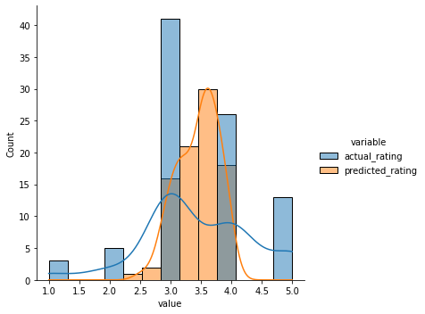

```python
predicted_ratings_for_interacted_movies = predict_already_interacted_ratings(rating, 7, similarity_algo_optimized_item)
df = predicted_ratings_for_interacted_movies.melt(id_vars='movieId', value_vars=['actual_rating', 'predicted_rating'])
sns.displot(data=df, x='value', hue='variable', kde=True);
```

Observation: Comparing the predicted ratings by similarity based recommendation system against actual ratings for userId=7

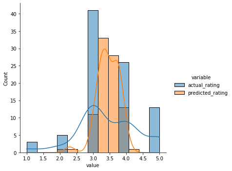

```python
predicted_ratings_for_interacted_movies = predict_already_interacted_ratings(rating, 7, svd_algo_optimized)
df = predicted_ratings_for_interacted_movies.melt(id_vars='movieId', value_vars=['actual_rating', 'predicted_rating'])
sns.displot(data=df, x='value', hue='variable', kde=True);
```

Observation: Comparing the predicted ratings by matrix factorization based recommendation system against actual ratings for userId=7

```python
reader = Reader(rating_scale=(0, 5))

data = Dataset.load_from_df(rating[['userId', 'movieId', 'rating']], reader)

trainset, testset = train_test_split(data, test_size=0.2, random_state=42)
```

```python
def precision_recall_at_k(predictions, k=10, threshold=3.5):
    """Return precision and recall at k metrics for each user"""

    user_est_true = defaultdict(list)
    for uid, _, true_r, est, _ in predictions:
        user_est_true[uid].append((est, true_r))

    precisions = dict()
    recalls = dict()
    for uid, user_ratings in user_est_true.items():

        user_ratings.sort(key=lambda x: x[0], reverse=True)

        n_rel = sum((true_r >= threshold) for (_, true_r) in user_ratings)

        n_rec_k = sum((est >= threshold) for (est, _) in user_ratings[:k])

        n_rel_and_rec_k = sum(((true_r >= threshold) and (est >= threshold))
                              for (est, true_r) in user_ratings[:k])


        precisions[uid] = n_rel_and_rec_k / n_rec_k if n_rec_k != 0 else 0



        recalls[uid] = n_rel_and_rec_k / n_rel if n_rel != 0 else 0

    return precisions, recalls
```

Observation: Compute the precision and recall, for each of the 6 models, at k = 5 and 10. This is 6 x 2 = 12 numerical values

```python
kf = KFold(n_splits=5)

K = [5, 10]

models = [algo_knn_user, similarity_algo_optimized_user,algo_knn_item,similarity_algo_optimized_item, algo_svd, svd_algo_optimized]

for k in K:
    for model in models:
        print('> k={}, model={}'.format(k,model.__class__.__name__))
        p = []
        r = []
        for trainset, testset in kf.split(data):
            model.fit(trainset)
            predictions = model.test(testset, verbose=False)
            precisions, recalls = precision_recall_at_k(predictions, k=k, threshold=3.5)

            p.append(sum(prec for prec in precisions.values()) / len(precisions))
            r.append(sum(rec for rec in recalls.values()) / len(recalls))

        print('-----> Precision: ', round(sum(p) / len(p), 3))
        print('-----> Recall: ', round(sum(r) / len(r), 3))
```

```
> k=5, model=KNNBasic
-----> Precision:  0.767
-----> Recall:  0.409
> k=5, model=KNNBasic
Computing the cosine similarity matrix...
Done computing similarity matrix.
Computing the cosine similarity matrix...
Done computing similarity matrix.
Computing the cosine similarity matrix...
Done computing similarity matrix.
Computing the cosine similarity matrix...
Done computing similarity matrix.
Computing the cosine similarity matrix...
Done computing similarity matrix.
-----> Precision:  0.767
-----> Recall:  0.417
> k=5, model=KNNBasic
-----> Precision:  0.611
-----> Recall:  0.328
> k=5, model=KNNBasic
-----> Precision:  0.686
-----> Recall:  0.359
> k=5, model=SVD
-----> Precision:  0.752
-----> Recall:  0.383
> k=5, model=SVD
-----> Precision:  0.747
-----> Recall:  0.386
> k=10, model=KNNBasic
-----> Precision:  0.751
-----> Recall:  0.549
> k=10, model=KNNBasic
Computing the cosine similarity matrix...
Done computing similarity matrix.
Computing the cosine similarity matrix...
Done computing similarity matrix.
Computing the cosine similarity matrix...
Done computing similarity matrix.
Computing the cosine similarity matrix...
Done computing similarity matrix.
Computing the cosine similarity matrix...
Done computing similarity matrix.
-----> Precision:  0.749
-----> Recall:  0.561
> k=10, model=KNNBasic
-----> Precision:  0.595
-----> Recall:  0.478
> k=10, model=KNNBasic
-----> Precision:  0.664
-----> Recall:  0.504
> k=10, model=SVD
-----> Precision:  0.74
-----> Recall:  0.522
> k=10, model=SVD
-----> Precision:  0.726
-----> Recall:  0.522
```

Observation: Compute the precision and recall, for each of the 6 models, at k = 5 and 10. This is 6 x 2 = 12 numerical values

7.1. Compare the results from the base line user-user and item-item based models

7.2. How do these baseline models compare to each other with respect to the tuned user-user and item-item models?

User-user and item-item collaborative filtering, can vary depending on factors such as the size and sparsity of the data, the similarity metric used, the method of recommendation

7.3. The matrix factorization model is different from the collaborative filtering models. Briefly describe this difference. Also, compare the RMSE and precision recall for the models.

Collaborative filtering methods, such as user-user and item-item CF, make recommendations by finding similarities between users or items based on their past behavior and Matrix factorization, on the other hand, is a type of dimensionality reduction technique that aims to represent the user-item interaction matrix as a lower-dimensional matrix that captures the latent features underlying the data.

7.4. Does it improve? Can you offer any reasoning as to why that might be?

Machine learning models can improve over time as new algorithms and techniques are developed, and as more data becomes available for training and evaluation.